# Prática no R! Roteiro 3 - Análise Exploratória II

Elaborado por Luis Felipe Bortolatto da Cunha

21 de setembro de 2020

# 1. Introdução

Este roteiro tem como objetivo apresentar novas funções para a execução **análise exploratória**, mas dessa vez baseadas no pacote **`tidyverse`** que estão organizadas em torno de um **conjunto de princípios básicos** que tornam a análise de dados mais acessível para quem está tendo o primeiro contato com a programação.

A Figura 1 ilustra 6 etapas fundamentais da análise de dados que o software R auxilia a executar.

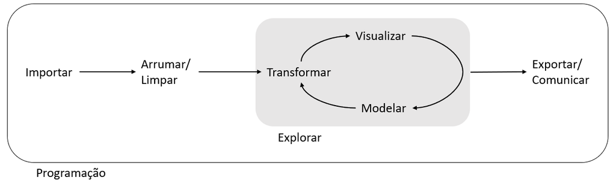

Fig. 1 - Etapas da análise de dados. Fonte: adaptado de Grolemund & Wickham, 2017

Nesse roteiro, utilizaremos duas bases de dados demográficos e de consumo de água de 2010, extraídas do Censo Demográfico (IBGE) e Sistema Nacional de Informações sobre Saneamento (SNIS), para uma amostra de 4.417 municípios, organizada por [Carmo et al., 2013](https://abrh.s3.sa-east-1.amazonaws.com/Sumarios/155/ea6a64ffc76c211d6b7749ab8444b626_bf87b0b219dd784ffa049f367598e626.pdf).

As bases de dados estão disponíveis para download no endereço abaixo:

https://1drv.ms/u/s!AjettDH-3Gbni9kLp9z7BUHOtvlrng?e=DKVRmS

# 1.1. Importando os dados

As duas bases de dados podem ser importadas conforme as instruções do Roteiro 2.

Como elas estão hospedadas na nuvem, também podem ser importadas com o endereço web como argumento, ao invés do endereço local, conforme o exemplo abaixo. É importante lembrar que a importação pelo endereço web exige conexão com a internet!

```r
agua1 <- read.csv2("https://raw.githubusercontent.com/luisfelipebr/mti/master/dados/agua1.csv",
                   encoding="UTF-8")
```

```r
rede1 <- read.csv2("https://raw.githubusercontent.com/luisfelipebr/mti/master/dados/rede1.csv",
                   encoding="UTF-8")
```

# 1.2. Explorando os dados

A função `names()` permite ver o nome das variáveis das bases de dados. Como os nomes estão codificados, as tabelas abaixo fornecem uma correspondência do código com a descrição da variável.

```r
names(agua1)
```

```
##  [1] "ID_IBGE"   "ID_SNIS"   "NOME_MUN"  "UF"        "REGIAO"    "PIB"
##  [7] "RENDAPITA" "GINI"      "IDH"       "IDH_CLASS" "GE012"     "AG001"
## [13] "AG020"     "AG022"
```

| Código | Descrição |
| --- | --- |
| ID_IBGE | Código IBGE (7 dígitos) |
| ID_SNIS | Código IBGE (6 dígitos) |
| NOME_MUN | Nome do Município |
| UF | Unidade da Federação |
| REGIAO | Região do País |
| PIB | PIB 2010 |
| RENDAPITA | Renda per Capita 2010 |
| GINI | Índice GINI 2010 |
| IDH | Índice de Desenvolvimento Humano 2010 |
| IDH_CLASS | Classificação do Índice de Desenvolvimento Humano 2010: Muito Alto >= 0,9; Alto >= 0,8; Médio >= 0,5; Baixo < 0,5 |
| GE012 | População Total Residente no Município |
| AG001 | População Total Atendida com Abastecimento de Água |
| AG020 | Volume Micromedido nas Economias Residenciais Ativas de Agua - 1.000 m3/ano |
| AG022 | Quantidade de Economias Residenciais Ativas Micromedidas |

```r
names(rede1)
```

```
## [1] "ID_IBGE" "UF"      "REGIAO"  "DOMICIL" "REDE"
```

| Código | Descrição |
| --- | --- |
| ID_IBGE | Código IBGE (7 dígitos) |
| UF | Unidade da Federação |
| REGIAO | Região do País |
| DOMICIL | Quantidade de Domicílios |
| REDE | Quantidade de Domicílios com Acesso à Rede Geral de Água |

# 2. Instalando e abrindo o pacote “tidyverse”

Para instalar o pacote `tidyverse`, usaremos a função `install.packages()`, com o nome do pacote entre aspas como argumento.

**ATENÇÃO: só é necessário instalar o pacote uma única vez em cada computador.**

```r
install.packages("tidyverse")
```

Após instalar o pacote, utilizamos a função `library()` para abri-lo, com o nome do pacote como argumento. Não é necessário colocar o nome do pacote entre aspas.

**ATENÇÃO: é necessário abrir o pacote todas as vezes que o programa R/RStudio é aberto ou a sessão é reiniciada.**

```r
library(tidyverse)
```

# 3. Conhecendo o operador pipe (`%>%`)

O **operador pipe (`%>%`)** é a principal contribuição do `tidyverse` à análise de dados. Ele é uma ferramenta poderosa para **expressar** de forma clara **uma sequencia de operações**.

Para entender como ele funciona, podemos traçar o paralelo com uma receita de bolo (curso-r, 2018). Usando o R básico, a receita poderia ser representada da seguinte forma:

```r
esfrie(
  asse(
    coloque(
      bata(
        acrescente(
          recipiente(
            rep("farinha", 2),
            "água",
            "fermento",
            "leite",
            "óleo"
          ),
          "farinha",
          ate = "macio"
        ),
        duracao = "3min"
      ),
      lugar = "forma",
      tipo = "grande",
      untada = TRUE
    ),
    duracao = "50min"
  ),
  lugar = "geladeira",
  duracao = "20min"
)
```

O R básico processa o que está em parênteses primeiro (assim como na matemática), tornando a leitura do código pouco intuitiva. O pipe funciona como um tubo que **conecta as etapas da análise de dados em ordem cronológica**, facilitando a leitura. O mesmo código escrito com o R básico, poderia ser representado com o pipe da seguinte forma:

```r
recipiente(rep("farinha", 2), "água", "fermento", "leite", "óleo") %>%
  acrescente("farinha", até = "macio") %>%
  bata(duração = "3min") %>%
  coloque(lugar = "forma", tipo = "grande", untada = TRUE) %>%
  asse(duração = "50min") %>%
  esfrie("geladeira", "20min")
```

Esperamos que esse exercício de abstração tenha convencido-o a adotar o operador pipe na análise de dados. A partir desse roteiro, o pipe será usado em todos os exemplos, apesar do seu uso ser opcional.

# 4. Filtrar e Selecionar (filter, select)

Enquanto no R básico a criação de subconjuntos exige o uso de colchetes, o tidyverse adiciona as funções: `filter()` para filtrar observações e `select()` para selecionar variáveis.

Tomemos o mesmo exemplo do Roteiro 2 - para visualizar o nome e IDH dos municípios que satisfazem as condições: Unidade da Federação é igual a São Paulo E IDH maior que 0,85.

No R básico, isso pode ser feito da seguinte forma:

```r
agua1[which(agua1$UF == "SP" & agua1$IDH > 0.85),c("NOME_MUN", "IDH")]
```

```
##                 NOME_MUN   IDH
## 3273  Águas de São Pedro 0.908
## 3375            Campinas 0.852
## 3560             Jundiaí 0.857
## 3754      Ribeirão Preto 0.855
## 3773            Saltinho 0.851
## 3795 Santana de Parnaíba 0.853
## 3809              Santos 0.871
## 3812  São Caetano do Sul 0.919
## 3903             Vinhedo 0.857
```

No tidyverse, ficaria assim:

```r
agua1 %>%
  filter(UF == "SP" & IDH > 0.85) %>%
  select(NOME_MUN, IDH)
```

```
##              NOME_MUN   IDH
## 1  Águas de São Pedro 0.908
## 2            Campinas 0.852
## 3             Jundiaí 0.857
## 4      Ribeirão Preto 0.855
## 5            Saltinho 0.851
## 6 Santana de Parnaíba 0.853
## 7              Santos 0.871
## 8  São Caetano do Sul 0.919
## 9             Vinhedo 0.857
```

# 5. Transformações (mutate)

Definir novas variáveis no R básico é bem simples. Mas para incluir essa etapa no fluxo do `tidyverse`, podemos usar a função `mutate()`.

Seguindo o exemplo do Roteiro 2, podemos definir as variáveis CONSUMO1 e CONSUMO2 da seguinte forma com o R básico:

- `CONSUMO1`: Consumo de Água per capita - População Total - m3/ano (AG020/GE012)
- `CONSUMO2`: Consumo de Água per capita - População Atendida - m3/ano (AG020/AG001)

```r
agua1$CONSUMO1 <- agua1$AG020 * 1000 / agua1$GE012
agua1$CONSUMO2 <- agua1$AG020 * 1000 / agua1$AG001
```

A mesma operação ficaria da seguinte forma no tidyverse:

```r
agua2 <- agua1 %>%
  mutate(CONSUMO1 = AG020 * 1000 / GE012,
         CONSUMO2 = AG020 * 1000 / AG001)
```

Vamos chamar o novo objeto de agua2, pois ele é igual à tabela que foi exportada com esse nome no Roteiro 2.

# 6. União (join)

Como supõe o nome, a união serve para unir duas bases de dados a partir de um identificador.

No tidyverse, a união pode ser feita usando uma de quatro funções, a depender do seu objetivo:

- `left_join()`: Adiciona à primeira base as variáveis da segunda base que possuem correspondência ao identificador.
- `right_join()`: Adiciona à segunda base as variáveis da primeira base possuem correspondência ao identificador.
- `inner_join()`: O resultado é uma base de dados que exclui as observações sem correspondência ao identificador.
- `full_join()`: O resultado é uma base de dados com todas as observações, da primeira e segunda base, adicionando valores faltantes (NA) quando não há correspondência ao identificador.

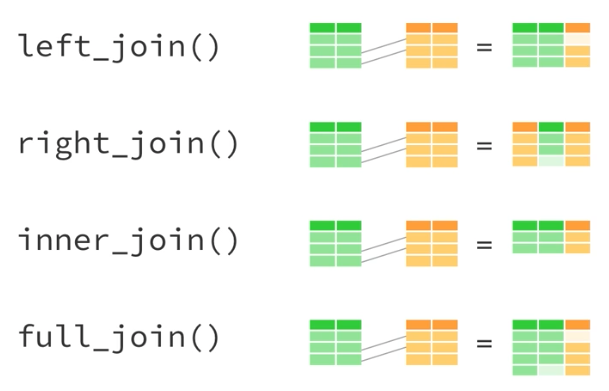

Fig. 2 - Tipos de união. Fonte: Surles, 2017

Neste roteiro vamos explorar a proporção de domicílios com acesso à rede geral de água (PROPREDE). A proporção de domicílios com acesso à rede geral pode ser calculada com a função `mutate()` para dividir a quantidade de domicílios com acesso à rede geral pela quantidade total de domicílios (REDE/DOMICIL).

- `PROPREDE`: Proporção de Domicílios com com Acesso à Rede Geral de Água (REDE/DOMICIL)

Como estes dados estão fragmentados em duas bases de dados diferentes, vamos uni-las com a função `full_join()`.

Além disso, como as duas bases de dados possuem variáveis repetidas usaremos a opção `select()` para selecionar apenas as variáveis de interesse.

Todas essas etapas da análise de dados podem ser escritas em um único fluxo de análise de dados com o tidyverse, da seguinte forma:

```r
agua_rede1 <- rede1 %>%
  mutate(PROPREDE = REDE/DOMICIL) %>%
  select(-c(UF, REGIAO)) %>%
  full_join(agua2, by = "ID_IBGE")
```

**ATENÇÃO: o sinal menos (-) significa que vamos selecionar TODAS as variáveis EXCETO as especificadas.**

# 7. Agrupar e resumir (group_by, summarize)

**Agrupar e resumir** são duas etapas da análise de dados, geralmente aplicadas juntas, para calcular estatísticas básicas em subconjuntos.

Na aula teórica, aprendemos a calcular o intervalo de confiança.

Para explorar a desigualdade de PROPREDE1, vamos primeiro filtrar os valores faltantes (`drop_na()`), agrupar por regiões (`group_by()`), resumir estatísticas básicas (`summarize()`) e calcular o intervalo de confiança para cada região (`mutate()`) com um intervalo de confiança de 95% (escore-z da curva normal é igual a 1,96). O resultado será salvo como o objeto de nome `tabela_PROPREDE`.

```r
tabela_PROPREDE <- agua_rede1 %>%
  drop_na(PROPREDE) %>%
  group_by(REGIAO) %>%
  summarize(n_obs = n(),
            media = mean(PROPREDE),
            desvio_padrao = sd(PROPREDE)) %>%
  mutate(erro = 1.96*desvio_padrao/sqrt(n_obs),
         limite_superior = media + erro,
         limite_inferior = media - erro)
```

É possível visualizar essa tabela chamando o seu nome.

```r
tabela_PROPREDE
```

```
## # A tibble: 5 x 7
##   REGIAO       n_obs media desvio_padrao    erro limite_superior limite_inferior
##   <chr>        <int> <dbl>         <dbl>   <dbl>           <dbl>           <dbl>
## 1 Centro-Oeste   466 0.694         0.160 0.0146            0.709           0.680
## 2 Nordeste      1789 0.654         0.189 0.00875           0.662           0.645
## 3 Norte          449 0.498         0.232 0.0214            0.520           0.477
## 4 Sudeste       1668 0.766         0.164 0.00786           0.774           0.758
## 5 Sul           1188 0.716         0.194 0.0110            0.727           0.705
```

# 8. Gráficos (ggplot)

Dentre os componentes do tidyverse, está o pacote `ggplot2`, que permite a criação de gráficos a partir de uma linguagem universal entre os programadores e designers, chamada de a gramática dos gráficos. Não é o objetivo deste roteiro explorar a visualização de dados em detalhes, mas os comandos abaixo mostram como construir alguns tipos de gráficos.

Com o pacote `ggplot2`, qualquer gráfico bidimensional pode ser construído partindo da função `ggplot()`, que segue a seguinte lógica:

ggplot(data = *base_de_dados*, aes(x = *codigo_variavel*, y = *codigo_variavel*)) + geom_*tipo_de_geometria*()

Em que os argumentos obrigatórios são:

- `data` = base de dados (tabela)
- `aes()` = estética. É aqui que você vai especificar os eixos *x* e *y* (se houver), assim como atributos adicionais como cor, tamanho, espessura e formato dos pontos/linhas/polígonos

Alguns dos tipos de geometria mais comuns são:

- `+ geom_histogram()` = histograma
- `+ geom_boxplot()` = box-plot
- `+ geom_point()` = gráfico de dispersão
- `+ geom_line()` = gráfico de linhas
- `+ geom_abline()` = reta de tendência (correlação)
- `+ geom_smooth()` = reta de tendência (regressão)
- `+ geom_bar()` = gráfico de barras (pré-tabulação/contagem)
- `+ geom_col()` = gráfico de barras (pós-tabulação/contagem)
- `+ geom_errorbar()` = barras de erro

Alguns argumentos adicionais que podem ser explorados são:

- `+ facet_wrap(~*codigo_variavel*)` = replica um gráfico para diferentes classes
- `+ coord_flip()` = inverte as coordenadas x e y
- `+ ggtitle("Título em parênteses")` = adiciona um título
- `+ theme()` = para customizar os componentes não relacionados aos dados

Argumentos adicionais podem ser consultados acessando a bibliografia complementar.

Vamos usar a função `ggplot()` para explorar com maior profundidade as desigualdades regionais relacionadas à PROPREDE.

O código abaixo desenha um histograma de PROPREDE:

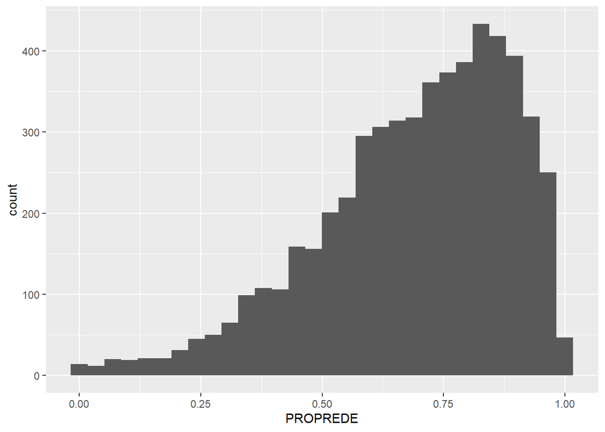

```r
ggplot(data = agua_rede1, aes(x = PROPREDE)) +
  geom_histogram()
```

Adicionando o argumento `facet_wrap()` é possível replicar esse gráfico para cada região:

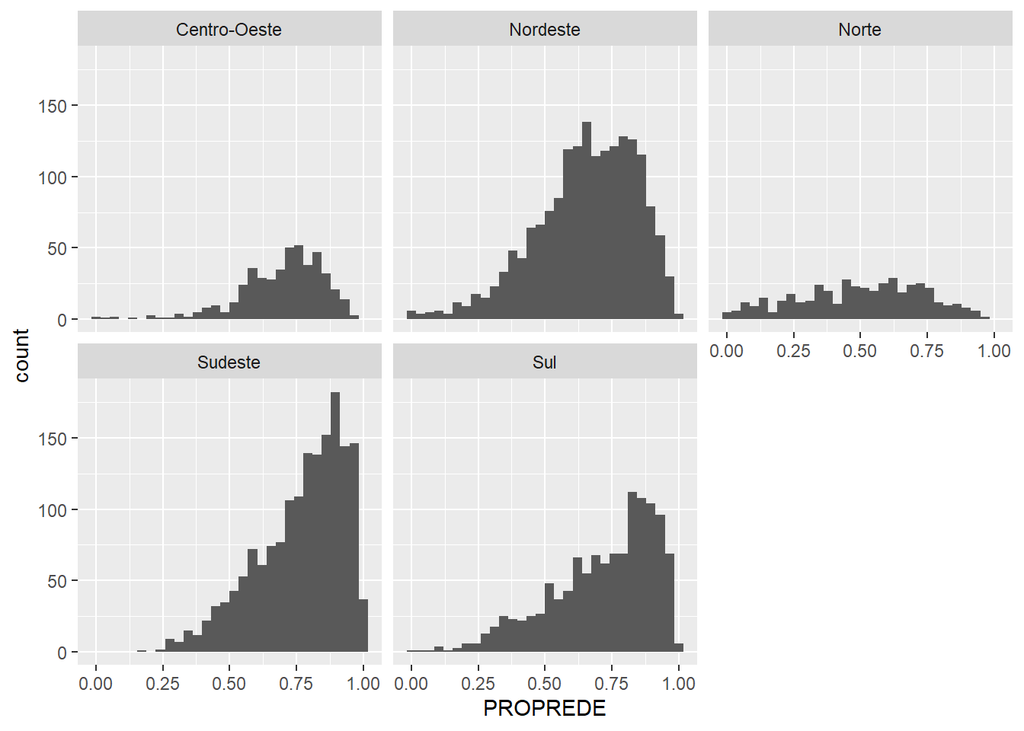

```r
ggplot(data = agua_rede1, aes(x = PROPREDE)) +
  geom_histogram() +
  facet_wrap(~REGIAO)
```

Adicionando mais alguns argumentos, a visualização do gráfico pode ser aprimorada ainda mais, embora essa etapa é opcional.

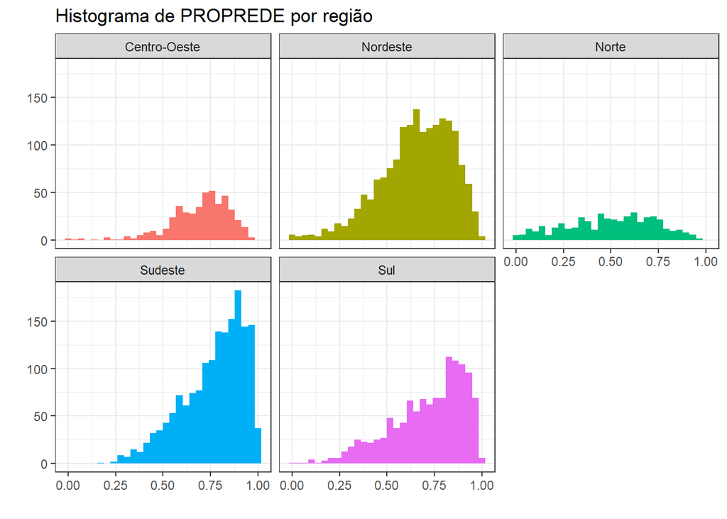

```r
ggplot(data = agua_rede1, aes(x = PROPREDE, fill = REGIAO)) +
  geom_histogram() +
  facet_wrap(~REGIAO) +
  ggtitle("Histograma de PROPREDE por região") +
  xlab("") +
  ylab("") +
  theme_bw() +
  theme(legend.position = "none")
```

O código abaixo desenha um box-plot que compara `PROPREDE` entre as regiões.

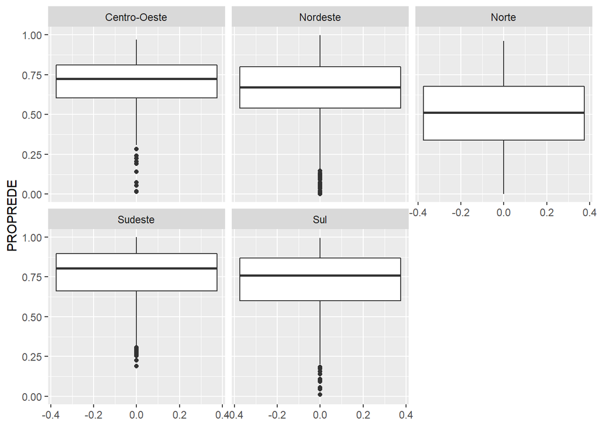

```r
ggplot(data = agua_rede1, aes(y = PROPREDE)) +
  geom_boxplot() +
  facet_wrap(~REGIAO)
```

Também é possível adicionar alguns argumentos para aprimorar a visualização desse gráfico.

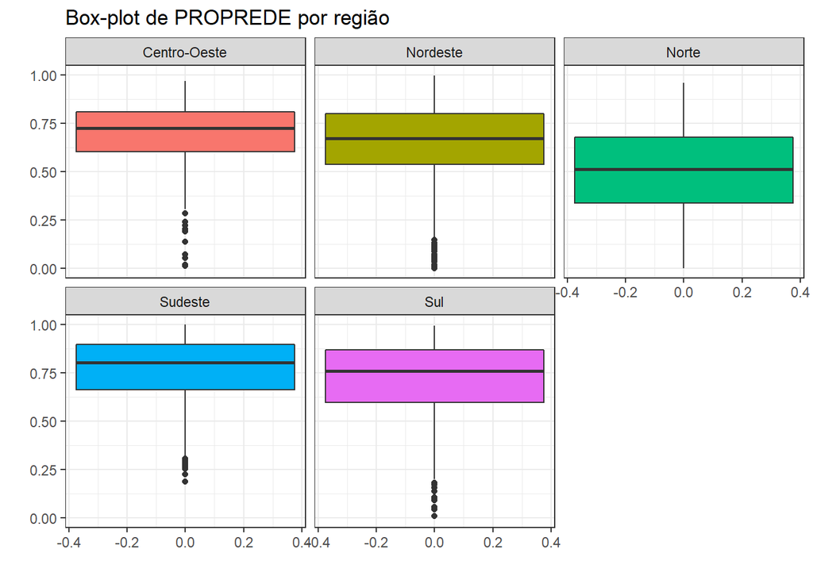

```r
ggplot(data = agua_rede1, aes(y = PROPREDE, fill = REGIAO)) +
  geom_boxplot() +
  facet_wrap(~REGIAO) +
  ggtitle("Box-plot de PROPREDE por região") +
  xlab("") +
  ylab("") +
  theme_bw() +
  theme(legend.position = "none")
```

Por fim, o gráfico abaixo compara a média e intervalo de confiança de `PROPREDE` por região.

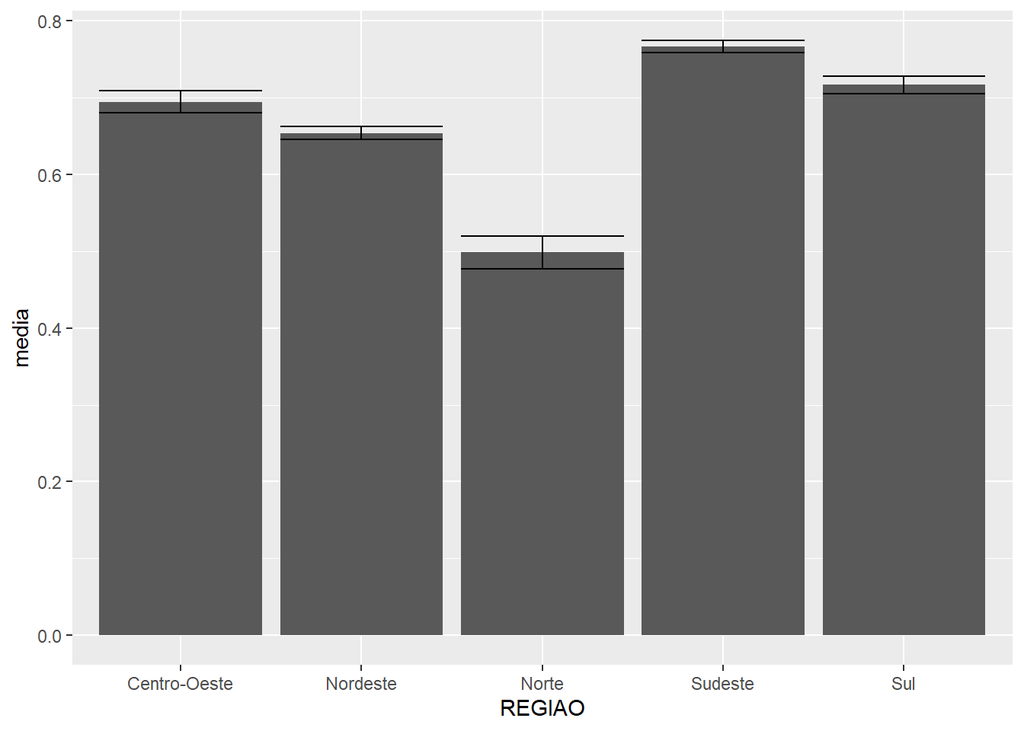

```r
ggplot(data = tabela_PROPREDE, aes(x = REGIAO, y = media)) +
  geom_col() +
  geom_errorbar(aes(ymin = limite_inferior, ymax = limite_superior))
```

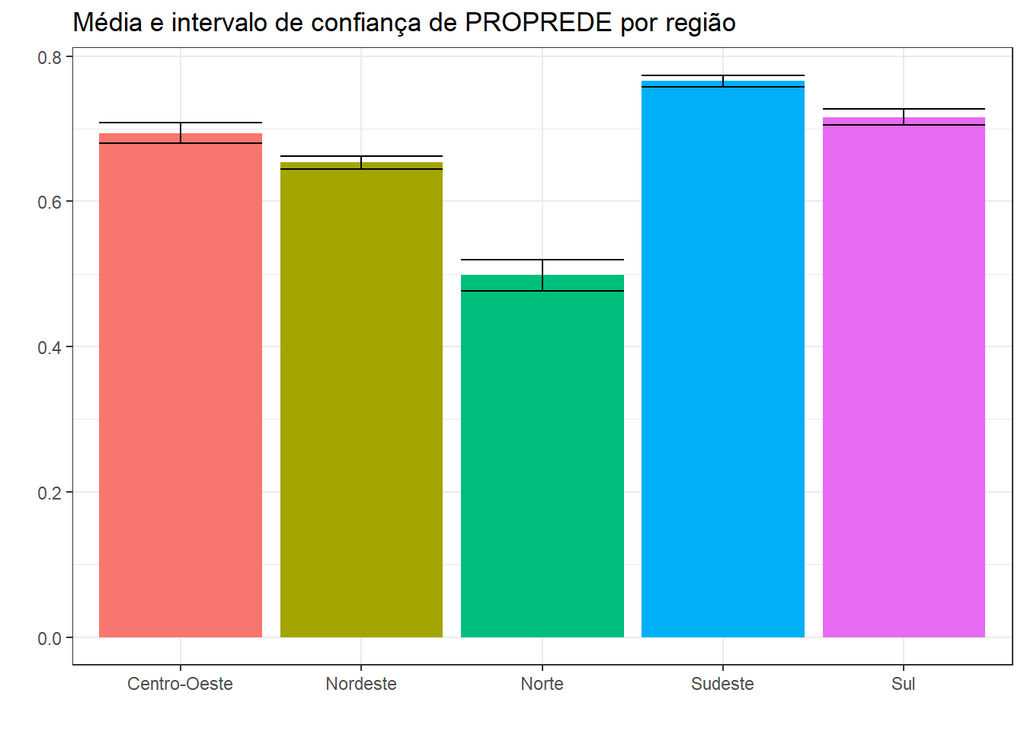

```r
ggplot(data = tabela_PROPREDE, aes(x = REGIAO, y = media, fill=REGIAO)) +
  geom_col() +
  geom_errorbar(aes(ymin = limite_inferior, ymax = limite_superior)) +
  ggtitle("Média e intervalo de confiança de PROPREDE por região") +
  xlab("") +
  ylab("") +
  theme_bw() +
  theme(legend.position = "none")
```

# 9. Exportando a base de dados

Não se esqueça de exportar a base de dados criada neste roteiro (`agua_rede1`), pois partiremos dela na próxima aula. Isso pode ser feito com a função `write.csv2`.

```r
write.csv2(agua_rede1, "dados/agua_rede1.csv", row.names = FALSE)
```